# Question

Las Torres del Paine en Magallanes es uno de los sitios turísticos más representativos de Chile. En la tabla se relaciona la cantidad de personas que ingresó cada día durante una semana, según el tipo de entrada que pagó.

Se pagan 43.000 pesos chilenos de entrada y 8.000 más si se realiza reserva.

Cantidad de personas que ingresaron

| Tipo de entrada | Lunes | Martes | Miércoles | Jueves | Viernes | Sábado | Domingo |
| --- | --- | --- | --- | --- | --- | --- | --- |
| Sin reserva | 300 | 300 | 600 | 700 | 400 | 300 | 700 |
| Con reserva | 600 | 700 | 200 | 600 | 500 | 600 | 500 |

El administrador diseñó el siguiente proceso para analizar la recaudación:

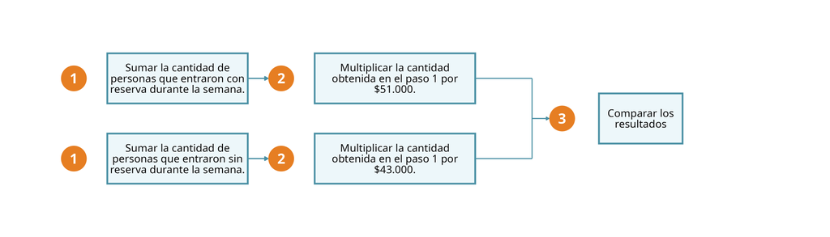

¿Cuál de las siguientes preguntas **NO** se puede resolver únicamente con la información obtenida mediante este proceso?

## Answerlist

- ¿En cuál día de la semana se recogió más dinero?
- ¿En cuál de los dos casos se recogió más dinero durante la semana?
- ¿Cuál fue la ganancia total de la Torres del Paine durante la semana?
- ¿Cuál fue el total de dinero recogido por ambos casos durante la semana?

# Solution

Para resolver este problema, debemos analizar qué información proporciona el proceso descrito:

**Información que SÍ se puede obtener del proceso:**

1. **Recaudación por tipo de entrada**: El proceso calcula cuánto dinero se recogió de personas con reserva (cantidad × 51.000 pesos chilenos) y sin reserva (cantidad × 43.000 pesos chilenos).
2. **Comparación entre casos**: El paso 3 permite comparar los resultados, determinando cuál tipo de entrada generó más ingresos.
3. **Total recaudado**: Sumando ambos resultados se obtiene el total de dinero recogido.

**Información que NO se puede obtener:**

- **Ganancia total**: La ganancia requiere conocer los costos operativos de la Torres del Paine (personal, mantenimiento, servicios, etc.), información que no está incluida en el proceso.
- **Día específico**: El proceso trabaja con totales de la semana, no con datos diarios.

# Meta-information

exname: proceso_recaudacion_sitio_turistico_numerico_variacional_argumentacion_n2_v1 extype: schoice exsolution: 0010 exshuffle: TRUE exsection: Numerico-Variacional/Argumentacion